# Introduction to TreeSummarizedExperiment

Ruizhu HUANG, Charlotte Soneson and Mark Robinson

Institute of Molecular Life Sciences, University of Zurich.  
SIB Swiss Institute of Bioinformatics.

11 May 2025

#### Package

TreeSummarizedExperiment 2.16.1

# 1 Introduction

The `TreeSummarizedExperiment` class is an extension of the `SingleCellExperiment` class (Lun and Risso 2020). It’s used to store rectangular data of experimental results as in a `SingleCellExperiment`, and also supports the storage of a hierarchical structure and its link information to the rectangular data.

# 2 TreeSummarizedExperiment

## 2.1 Anatomy of TreeSummarizedExperiment

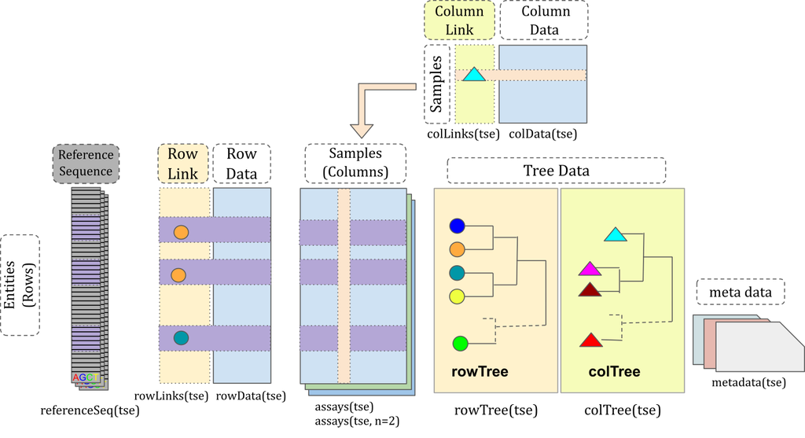

Figure 1: The structure of the TreeSummarizedExperiment class

Compared to the `SingleCellExperiment` objects, `TreeSummarizedExperiment` has five additional slots:

- `rowTree`: the hierarchical structure on the rows of the `assays`.
- `rowLinks`: the link information between rows of the `assays` and the `rowTree`.
- `colTree`: the hierarchical structure on the columns of the `assays`.
- `colLinks`: the link information between columns of the `assays` and the `colTree`.
- `referenceSeq` (optional): the reference sequence data per feature (row).

The `rowTree` and$/$or `colTree` can be left empty (`NULL`) if no trees are available; in this case, the `rowLinks` and$/$or `colLinks` are also set to `NULL`. All other `TreeSummarizedExperiment` slots are inherited from `SingleCellExperiment`.

The `referenceSeq` slot is optional. It accepts the reference sequence data of features either as `DNAStringSet` or `DNAStringSetList`. More details are in 2.4.3.

Functions in the *TreeSummarizedExperiment* package fall in two main categories: operations on the `TreeSummarizedExperiment` object or operations on the tree (`phylo`) objects. The former includes constructors and accessors, and the latter serves as “pieces” to be assembled as accessors or functions that manipulate the `TreeSummarizedExperiment` object. Given that more than 200 R packages make use of the `phylo` class, there are many resources (e.g., *ape*) for users to manipulate the small “pieces” in addition to those provided in *TreeSummarizedExperiment*.

## 2.2 Toy data

We generate a toy dataset that has observations of 6 entities collected from 4 samples as an example to show how to construct a `TreeSummarizedExperiment` object.

```r
library(TreeSummarizedExperiment)

# assays data (typically, representing observed data from an experiment)
assay_data <- rbind(rep(0, 4), matrix(1:20, nrow = 5))
colnames(assay_data) <- paste0("sample", 1:4)
rownames(assay_data) <- paste("entity", seq_len(6), sep = "")
assay_data
```

```
##         sample1 sample2 sample3 sample4
## entity1       0       0       0       0
## entity2       1       6      11      16
## entity3       2       7      12      17
## entity4       3       8      13      18
## entity5       4       9      14      19
## entity6       5      10      15      20
```

The information of entities and samples are given in the **row_data** and **col_data**, respectively.

```r
# row data (feature annotations)
row_data <- data.frame(Kingdom = "A",
                       Phylum = rep(c("B1", "B2"), c(2, 4)),
                       Class = rep(c("C1", "C2", "C3"), each = 2),
                       OTU = paste0("D", 1:6),
                       row.names = rownames(assay_data),
                       stringsAsFactors = FALSE)

row_data
```

```
##         Kingdom Phylum Class OTU
## entity1       A     B1    C1  D1
## entity2       A     B1    C1  D2
## entity3       A     B2    C2  D3
## entity4       A     B2    C2  D4
## entity5       A     B2    C3  D5
## entity6       A     B2    C3  D6
```

```r
# column data (sample annotations)
col_data <- data.frame(gg = c(1, 2, 3, 3),
                       group = rep(LETTERS[1:2], each = 2),
                       row.names = colnames(assay_data),
                       stringsAsFactors = FALSE)
col_data
```

```
##         gg group
## sample1  1     A
## sample2  2     A
## sample3  3     B
## sample4  3     B
```

```r
library(ape)

# The first toy tree
set.seed(12)
row_tree <- rtree(5)

# The second toy tree
set.seed(12)
col_tree <- rtree(4)

# change node labels
col_tree$tip.label <- colnames(assay_data)
col_tree$node.label <- c("All", "GroupA", "GroupB")
```

We visualize the tree using the package *ggtree* (Yu et al. 2017). Here, the internal nodes of the **row_tree** have no labels as shown in Figure 2.

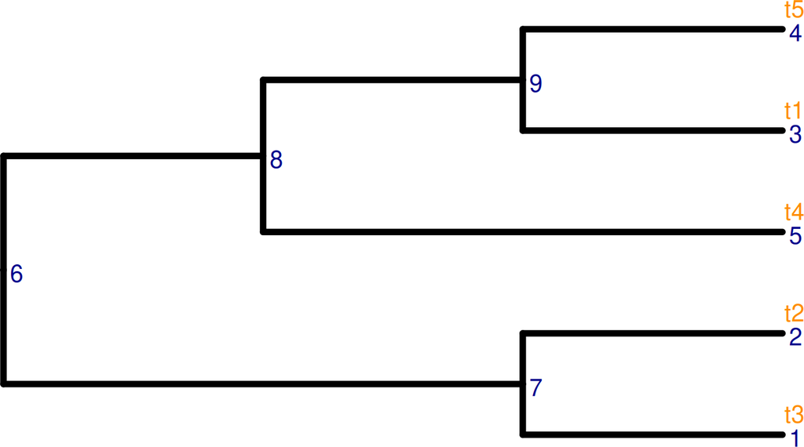

Figure 2: The structure of the row tree  
The node labels and the node numbers are in orange and blue text, respectively.

```r
library(ggtree)
library(ggplot2)

# Visualize the row tree
ggtree(row_tree, size = 2, branch.length = "none") +
    geom_text2(aes(label = node), color = "darkblue",
               hjust = -0.5, vjust = 0.7, size = 5.5) +
    geom_text2(aes(label = label), color = "darkorange",
               hjust = -0.1, vjust = -0.7, size = 5.5)
```

The **col_tree** has labels for internal nodes.

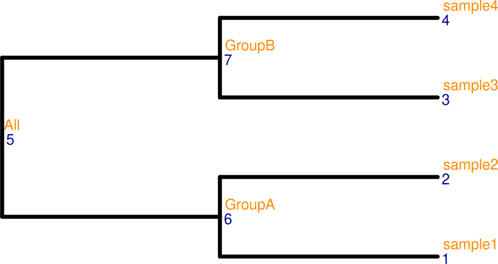

Figure 3: The structure of the column tree  
The node labels and the node numbers are in orange and blue text, respectively.

```r
# Visualize the column tree
ggtree(col_tree, size = 2, branch.length = "none") +
    geom_text2(aes(label = node), color = "darkblue",
               hjust = -0.5, vjust = 0.7, size = 5.5) +
    geom_text2(aes(label = label), color = "darkorange",
               hjust = -0.1, vjust = -0.7, size = 5.5)+
    ylim(c(0.8, 4.5)) +
    xlim(c(0, 2.2))
```

## 2.3 The construction of `TreeSummarizedExperiment`

The `TreeSummarizedExperiment` class is used to store the toy data generated in the previous section: **assay_data**, **row_data**, **col_data**, **col_tree** and **row_tree**. To correctly store data, the link information between the rows (or columns) of **assay_data** and the nodes of the **row_tree** (or **col_tree**) can be provided via a character vector `rowNodeLab` (or `colNodeLab`), with length equal to the number of rows (or columns) of the `assays`; otherwise the row (or column) names are used. Those columns or rows with labels that are not present among the node labels of the tree are removed with warnings. The link data between the `assays` tables and the tree data is automatically generated in the construction.

The row and column trees can be included simultaneously in the construction. Here, the column names of **assay_data** can be found in the node labels of the column tree, which enables the link to be created between the column dimension of **assay_data** and the column tree **col_tree**. If the row names of **assay_data** are not in the node labels of **row_tree**, we would need to provide their corresponding node labels (**row_lab**) to `rowNodeLab` in the construction of the object. It is allowed to have multiple rows or/and columns mapped to a node, for example, the same leaf label is used for the first two rows in **row_lab**.

```r
# all column names could be found in the node labels of the column tree
all(colnames(assay_data) %in% c(col_tree$tip.label, col_tree$node.label))
```

```
## [1] TRUE
```

```r
# provide the node labels in rowNodeLab
tip_lab <- row_tree$tip.label
row_lab <- tip_lab[c(1, 1:5)]
row_lab
```

```
## [1] "t3" "t3" "t2" "t1" "t5" "t4"
```

```r
both_tse <- TreeSummarizedExperiment(assays = list(Count = assay_data),
                                     rowData = row_data,
                                     colData = col_data,
                                     rowTree = row_tree,
                                     rowNodeLab = row_lab,
                                     colTree = col_tree)
```

```r
both_tse
```

```
## class: TreeSummarizedExperiment
## dim: 6 4
## metadata(0):
## assays(1): Count
## rownames(6): entity1 entity2 ... entity5 entity6
## rowData names(4): Kingdom Phylum Class OTU
## colnames(4): sample1 sample2 sample3 sample4
## colData names(2): gg group
## reducedDimNames(0):
## mainExpName: NULL
## altExpNames(0):
## rowLinks: a LinkDataFrame (6 rows)
## rowTree: 1 phylo tree(s) (5 leaves)
## colLinks: a LinkDataFrame (4 rows)
## colTree: 1 phylo tree(s) (4 leaves)
```

When printing out **both_tse**, we see a similar message as `SingleCellExperiment` with four additional lines for `rowLinks`, `rowTree`, `colLinks` and `colTree`.

## 2.4 The accessor functions

### 2.4.1 Assays, rowData, colData, and metadata

For slots inherited from the `SingleCellExperiment` class, the accessors are exactly the same as shown in *SingleCellExperiment*. These accessors are both setters and getters.

```r
# to get the first table in the assays
(count <- assays(both_tse)[[1]])
```

```
##         sample1 sample2 sample3 sample4
## entity1       0       0       0       0
## entity2       1       6      11      16
## entity3       2       7      12      17
## entity4       3       8      13      18
## entity5       4       9      14      19
## entity6       5      10      15      20
```

```r
# to get row data
rowData(both_tse)
```

```
## DataFrame with 6 rows and 4 columns
##             Kingdom      Phylum       Class         OTU
##         <character> <character> <character> <character>
## entity1           A          B1          C1          D1
## entity2           A          B1          C1          D2
## entity3           A          B2          C2          D3
## entity4           A          B2          C2          D4
## entity5           A          B2          C3          D5
## entity6           A          B2          C3          D6
```

```r
# to get column data
colData(both_tse)
```

```
## DataFrame with 4 rows and 2 columns
##                gg       group
##         <numeric> <character>
## sample1         1           A
## sample2         2           A
## sample3         3           B
## sample4         3           B
```

```r
# to get metadata: it's empty here
metadata(both_tse)
```

```
## list()
```

### 2.4.2 rowTree, colTree, rowLinks, colLinks

For new slots, we provide `rowTree` (and `colTree`) to retrieve the row (column) trees, and `rowLinks` (and `colLinks`) to retrieve the link information between `assays` and nodes of the row (column) tree. If the tree is not available, the corresponding link data is `NULL`.

```r
# get trees
rowTree(both_tse)
```

```
##
## Phylogenetic tree with 5 tips and 4 internal nodes.
##
## Tip labels:
##   t3, t2, t1, t5, t4
##
## Rooted; includes branch length(s).
```

```r
colTree(both_tse)
```

```
##
## Phylogenetic tree with 4 tips and 3 internal nodes.
##
## Tip labels:
##   sample1, sample2, sample3, sample4
## Node labels:
##   All, GroupA, GroupB
##
## Rooted; includes branch length(s).
```

`rowTree` and `colTree` can work not only as getters but also as setters. The replacement requires that the row/col names of the **TSE** object can be matched to node labels of the new row/col tree; otherwise `changeTree` should be used with `rowNodeLab` or `colNodeLab` available 2.6.

```r
new_tse <- both_tse

# a new tree
new_tree <- rtree(nrow(new_tse))
new_tree$tip.label <- rownames(new_tse)

# the original row tree is replaced with the new tree
rowTree(new_tse) <- new_tree
identical(rowTree(new_tse), rowTree(both_tse))
```

```
## [1] FALSE
```

```r
identical(rowTree(new_tse), new_tree)
```

```
## [1] TRUE
```

`rowLinks` and `colLinks` only work as getters.

```r
# access the link data
(r_link <- rowLinks(both_tse))
```

```
## LinkDataFrame with 6 rows and 5 columns
##             nodeLab nodeLab_alias   nodeNum    isLeaf   whichTree
##         <character>   <character> <integer> <logical> <character>
## entity1          t3       alias_1         1      TRUE       phylo
## entity2          t3       alias_1         1      TRUE       phylo
## entity3          t2       alias_2         2      TRUE       phylo
## entity4          t1       alias_3         3      TRUE       phylo
## entity5          t5       alias_4         4      TRUE       phylo
## entity6          t4       alias_5         5      TRUE       phylo
```

```r
(c_link <- colLinks(both_tse))
```

```
## LinkDataFrame with 4 rows and 5 columns
##             nodeLab nodeLab_alias   nodeNum    isLeaf   whichTree
##         <character>   <character> <integer> <logical> <character>
## sample1     sample1       alias_1         1      TRUE       phylo
## sample2     sample2       alias_2         2      TRUE       phylo
## sample3     sample3       alias_3         3      TRUE       phylo
## sample4     sample4       alias_4         4      TRUE       phylo
```

- `nodeLab`: the labels of nodes on the tree
- `nodeLab_alias`: the alias labels of nodes on the tree
- `nodeNum`: the numbers of nodes on the tree
- `isLeaf`: whether the node is a leaf node
- `whichTree`: the name of the tree that is mapped to (See vignette 2).

More details about the `DataFrame` class could be found in the *S4Vectors* R/Bioconductor package.

```r
class(r_link)
```

```
## [1] "LinkDataFrame"
## attr(,"package")
## [1] "TreeSummarizedExperiment"
```

```r
showClass("LinkDataFrame")
```

```
## Class "LinkDataFrame" [package "TreeSummarizedExperiment"]
##
## Slots:
##
## Name:           rownames             nrows       elementType   elementMetadata
## Class: character_OR_NULL           integer         character DataFrame_OR_NULL
##
## Name:           metadata          listData
## Class:              list              list
##
## Extends:
## Class "DFrame", directly
## Class "LinkDataFrame_Or_NULL", directly
## Class "DataFrame", by class "DFrame", distance 2
## Class "SimpleList", by class "DFrame", distance 2
## Class "RectangularData", by class "DFrame", distance 3
## Class "List", by class "DFrame", distance 3
## Class "DataFrame_OR_NULL", by class "DFrame", distance 3
## Class "Vector", by class "DFrame", distance 4
## Class "list_OR_List", by class "DFrame", distance 4
## Class "Annotated", by class "DFrame", distance 5
## Class "vector_OR_Vector", by class "DFrame", distance 5
```

The link data is automatically generated when constructing the `TreeSummarizedExperiment` object. We highly recommend users not to modify it manually; otherwise the link might be broken. For R packages developers, we show in the Section 2.9 about how to update the link.